# Developing Data Products Week 4 Assignment

Ryan Sanders

10/25/2018

## Predicting fuel efficiency (miles per gallon)

The goal of this application is to see what predictors are best for predicting fuel efficiency using a linear model. The dataset used is mtcars.

Evaluation is done simplisticly based on the R squared and adjusted R squared values, to show the variance explained by the model. Adding predictors always increases the R squared (albeit some times by a small amount), but the adjusted R squared can go up or down.

Not all possible predictors are considered. I chose what I thought were likely to be the best predictors. Let’s see how good that selection was, as well as the best predictors from that selection.

## Using lasso to select features – build model

Using the lasso with cross validation to select features, can see that constraining a linear model (through lambda) results in a lower mean squared error than using all available predictors.

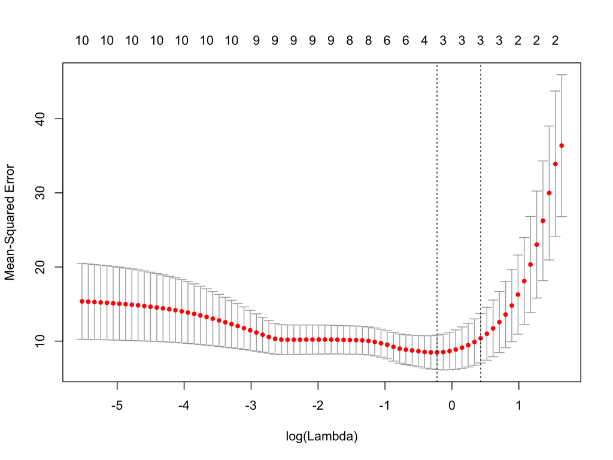

```r
x <- model.matrix(mpg ~ ., mtcars)[, -1]
y <- mtcars$mpg

model <- cv.glmnet(x, y, alpha = 1)
plot(model)
```

## Using lasso to select features – check coefficients

Interestingly the features selected are different to the ones I chose. Displacement and number of forward gears are excluded, horsepower is included.

```r
best_lambda <- model$lambda.min

grid <- 10^seq(10, -2, length = 100)

out <- glmnet(x, y, alpha = 1, lambda = grid)

coefficients <- predict(out, type = "coefficients", s = best_lambda)
coefficients
```

```
## 11 x 1 sparse Matrix of class "dgCMatrix"
##                        1
## (Intercept) 35.983319015
## cyl         -0.884017348
## disp         .
## hp          -0.011733153
## drat         .
## wt          -2.705884148
## qsec         .
## vs           .
## am           0.009294707
## gear         .
## carb         .
```

## Correlation between predictors

There is a high correlation between certain predictors, eg, displacement and cylinders, displacement and number of cylinders and, horsepower and number of cylinders. Interestingly the lasso chose both horsepower and number of cylinders even though they are highly correlated.

Out of the subset I selected, the best adjusted R squared was achieved with weight and number of cylinders. Displacement is also highly correlated with weight.

```r
cor(mtcars[, -1])
```

```
##             cyl       disp         hp        drat         wt        qsec
## cyl   1.0000000  0.9020329  0.8324475 -0.69993811  0.7824958 -0.59124207
## disp  0.9020329  1.0000000  0.7909486 -0.71021393  0.8879799 -0.43369788
## hp    0.8324475  0.7909486  1.0000000 -0.44875912  0.6587479 -0.70822339
## drat -0.6999381 -0.7102139 -0.4487591  1.00000000 -0.7124406  0.09120476
## wt    0.7824958  0.8879799  0.6587479 -0.71244065  1.0000000 -0.17471588
## qsec -0.5912421 -0.4336979 -0.7082234  0.09120476 -0.1747159  1.00000000
## vs   -0.8108118 -0.7104159 -0.7230967  0.44027846 -0.5549157  0.74453544
## am   -0.5226070 -0.5912270 -0.2432043  0.71271113 -0.6924953 -0.22986086
## gear -0.4926866 -0.5555692 -0.1257043  0.69961013 -0.5832870 -0.21268223
## carb  0.5269883  0.3949769  0.7498125 -0.09078980  0.4276059 -0.65624923
##              vs          am       gear        carb
## cyl  -0.8108118 -0.52260705 -0.4926866  0.52698829
## disp -0.7104159 -0.59122704 -0.5555692  0.39497686
## hp   -0.7230967 -0.24320426 -0.1257043  0.74981247
## drat  0.4402785  0.71271113  0.6996101 -0.09078980
## wt   -0.5549157 -0.69249526 -0.5832870  0.42760594
## qsec  0.7445354 -0.22986086 -0.2126822 -0.65624923
## vs    1.0000000  0.16834512  0.2060233 -0.56960714
## am    0.1683451  1.00000000  0.7940588  0.05753435
## gear  0.2060233  0.79405876  1.0000000  0.27407284
## carb -0.5696071  0.05753435  0.2740728  1.00000000
```